# Q1 데이터 분석 절차 중 어느 단계에 대한 설명인지 알맞게 연결하시오

## A 설문조사 결과에서 결측값을 찾아 제거하였다.

## B 주어진 데이터에 대해 군집 분석과 분류 분석을 실시하였다.

## C 데이터의 분포를 확인하고 주요 변수 간의 상관관계를 분석하였다.

## D 고객 이탈 원인을 파악하기 위해 분석 계획을 수립하였다.

## E 공공데이터포털에서 인구 통계 데이터를 다운로드하고, 설문조사를 통해 추가 데이터를 수집하였다.

## F 분석 결과를 시각화하여 보고서를 작성하고, 경영진에게 발표하였다.

### i. 문제의 정의 및 계획

### ii. 데이터 수집

### iii. 데이터 정제 및 전처리

### iv. 데이터 탐색

### v. 데이터 분석

### vi. 결과 보고

A -> iii 데이터 정제 및 전처리

B -> v 데이터 분석

C -> iv 데이터 탐색

D -> i 문제의 정의 및 계획

E -> ii 데이터 수집

F -> vi 결과 보고

# Q2 머신 알고리즘들을 알맞게 연결하시오

## A. 지도학습

## B. 비지도학습

### i. 군집

### ii. 분류

### iii. 이상치 탐지

### iv. 밀도추정

### v. 회귀

A : ii 분류, v 회귀

B : i 군집, iii 이상치 탐지, iv 밀도추정

# Q3 지도학습의 내용으로 틀린 것을 고르시오

## ① 문제와 답을 함께 학습함으로써 미지의 문제에 대한 올바른 답을 예측하는 학습

## ② 레이블 된 훈련 데이터에서 모델을 학습하여 본 적 없는 미래 데이터에 대해 예측을 만드는 것이 주요목적이다.

## ③ 컴퓨터가 세상에 존재하는 규칙을 스스로 시뮬레이션 하면서 게임처럼 규칙을 학습하는 방법

## ④ 모델로는 KNN, 의사 결정 트리, 선형회귀 등이 있다.

## ⑤ 지도학습 알고리즘은 과거/훈련 데이터에서 '학습'하고 이를 알 수 없는 입력에 적용하여 올바른 출력을 도출하는 것 이다.

답 : ③

# Q4 비지도학습의 내용으로 틀린 것을 고르시오

## ① 기존에 모여 있던 데이터에 대해 따로 분류 기준을 주지 않고 모델이 스스로 분류 기준을 찾아 집단을 모으는 기법

## ② 새로운 패턴을 식별하고 이상을 감지하는 데 사용되는 머신 러닝 알고리즘

## ③ 학습 알고리즘에 제공되는 데이터에는 레이블이 지정되지 않다

## ④ 비지도 학습된 모델은 결과를 만들 수 없다.

## ⑤ 모델로는 K-means, PCA, Kernel PCA 등이 있다.

답 : ④

# Q5 보기에 알맞은 학습 방법을 연결하시오

## A. 샘플 없음, 라벨 있음

## B. 샘플 범주,수치, 라벨 범주

## C. 샘플 범주,수치, 라벨 수치

## D. 셈플 범주,수치 라벨 없음

### i. 비지도학습

### ii. 학습불가

### iii. 지도학습 회귀

### iv. 지도학습 분류

A -> i B -> iv C -> iii D -> iv

# Q6 앙상블 모델에 관한 내용으로 틀린 것을 모두 고르시오

## ① 학습 성능향상

## ② 과대적합 방지

## ③ 모델의 해석 정도 향상

## ④ 학습 속도 저하

## ⑤ 다양한모델을 사용할수록 반드시 성능 증가

답 : ①, ⑤

# Q7 다음 그래프 중 가장 강한 양의 상관관계를 가진 그래프를 고르시오.

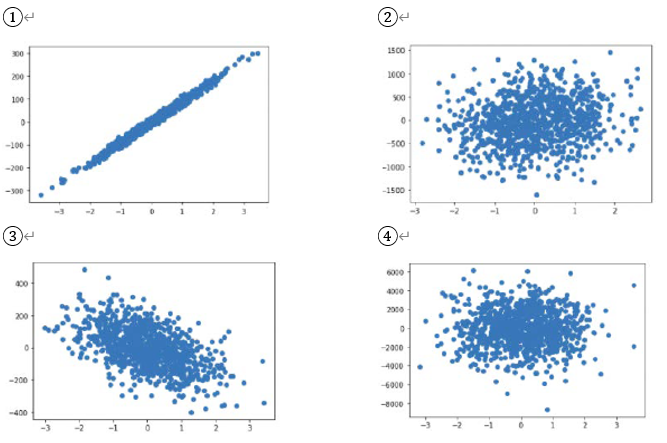

답 : ①

# Q8 다음 중 분류와 회귀에 대한 설명으로 틀린 것을 고르시오.

## ① 분류 문제의 결과로 데이터를 그룹으로 묶을 수 있다.

## ② 분류 문제의 결과 클래스가 3개 이상일 때는 기계학습으로 해결할 수 없다.

## ③ 레이블이 연속적인 값을 가질 때 회귀 문제의 해결 방식을 적용한다.

## ④ 범주형 자료형의 종류에는 명목형과 순서형이 있다.

답 : ④

# Q9 전체-배치 경사하강법(full-batch gradient descent) 방식과 미니-배치 경사하강법(minibatch gradient descent) 방식의 차이점에 대해서 바르게 설명한 것을 고르시오.

## ① 전체-배치 경사하강법은 모든 데이터를 한 번에 넣고 미니-배치 경사하강법은 데이터를 n개로 나누어 학습한다.

## ② 미니-배치 경사하강법에서 데이터를 나눌 때 일반적으로 10의 배수로 데이터를 나눈다.

## ③ 전체-배치 경사하강법을 할 때 데이터를 셔플(shuffle) 하게 되면, 데이터 입력의 일관성이 틀어져 학습 결과가 나빠진다.

## ④ 미니-배치 경사하강법에서는 1개의 데이터만 넣을 수 없다.

답 : ①

# Q10 회귀식의 성능을 측정하기 위해 사용되는 MAE, RMSE, 결정계수(R-squared)에 대한 설명으로 적절한 것을 고르시오.

## ① RMSE는 예측값과 실제값의 차이에 대한 제곱을 모두 합한 후 제곱근 연산을 한 값에 음수곱을 취한 값이다.

## ② MAE는 예측값과 실제값 간의 차이에 대한 합을 데이터 개수n 으로 나눈 값으로 계산된다.

## ③ 결정계수(R-squared)는 두 값의 상관도를 지표화하여 -10에서 10까지의 값을 출력한다.

## ④ MAE는 0에 수렴할수록 좋고, 결정계수는 1에 수렴할수록 좋은 결과 이다. 이상치가 많을 경우에는 RMSE가 MAE보다 왜곡 정도를 좀 더 효과적으로 표현한다.

답 : ④

# Q11 경사하강법에서 학습률(learning rate)과 반복(iteration) 횟수가 중요한 하이퍼 매개변수인 이유로 맞는 설명을 고르시오.

## ① 학습률이 크면 클수록 학습의 속도가 빨라져 최종 성능이 높아진다.

## ② 반복이 많을수록 최종 성능이 높아진다.

## ③ 학습률이 너무 작을 경우 학습 시간이 늦어지고, 반복이 충분하지 않을 경우 손실(loss)이 수렴되지 않는다.

## ④ 학습률이 작으면 세부적인 학습이 가능하며, 학습의 정확도를 위해 작게 하는 것이 좋다.

답 : ①

# Q12 확률적 경사하강법(SGD)을 사용하는 이유가 무엇인지 고르시오.

## ① 확률적 경사하강법을 사용할 경우, 일반적인 경사하강법에 비해 빠른 시간에 학습을 완료할 수 있다.

## ② 일반적 경사하강법은 학습에 소모되는 자원이 확률적 경사 하강법에 비해 많다.

## ③ 확률적 경사하강법은 매 에포크(epoch)마다 데이터를 랜덤으로 학습시켜 학습이 안장점(saddle point)을 빠져나와 최적점을 찾을 수 있도록 한다.

## ④ 확률적 경사하강법은 데이터를 한 번에 모두 넣고 학습하기 때문에 학습 속도가 빨라진다

답 : ③

# Q13 다음 중 과대적합과 과소적합을 올바르게 표현하지 못한 것을 고르시오

## ① 과대적합인 모델은 훈련 세트의 점수가 높습니다.

## ② 과대적합인 모델은 테스트 세트의 점수도 높습니다.

## ③ 과소적합인 모델은 훈련 세트의 점수가 낮습니다.

## ④ 과소적합인 모델은 테스트 세트의 점수도 낮습니다.

답 : ②

# Q14 보기에 알맞은 용어를 연결하시오

## A 데이터의 차원을 낮추는 작업

## B 주어진 대상 데이터들을 유사성이 높은 것들끼리 묶어주는 작업

## C 그룹이 알려진 데이터에서 그룹을 모르는 어떤 데이터에 대해 어느 그룹에 속하는지를 예측하는 작업

## D 독립변수(들)를 이용하여 종속변수의 값(연속형)을 예측하는 작업

## E 차원 축소를 시행하기에 전에 각 변수의 값을 일정 범위로 변환하는 작업

### i. 회귀(regression)

### ii. 군집화(clustering)

### iii. 분류(classification)

### iv. 데이터 스케일링(data scaling)

### v. 차원 축소(dimension reduction)

A -> v 차원 축소

B -> ii 군집화

C -> iii 분류

D -> i 회귀

E -> iv 데이터 스케일링

# Q15 다음 두 수식은 정규화를 위한 기법이다. 이에 대한 설명으로 옳은 것을 고르시오.

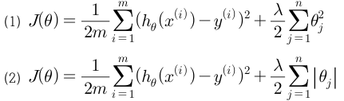

## ① (1) 식에서 $\lambda $ 값이 작으면 전체 손실(loss) 값이 0이 될 수 있다.

## ② (2) 식에서 $\lambda $ 값이 크면 클수록 손실(loss) 값이 줄어드는 효과가 나타난다.

## ③ (2) 식은 각 피쳐들의 가중치가 0이 될 수 있으며, 이로 인해 피쳐 선택( feature selection)이 가능하다.

## ④ (1) 식을 라쏘 회귀, (2) 식을 리지 회귀라고 부른다

# Q16 다중 클래스 분류 확률을 출력하기위해서 사용하는 함수를 고르시오

## ① 소프트맥스함수

## ② 시그모이드

## ③ 로그함수

## ④ 지수함수

답 : ①

# Q17 이미지 분류에서 주로 활용되는 활성화 함수를 고르시오(3)

## ① linear

## ② sigmoid

## ③ relu

## ④ tanh

# Q18 설명에 해당되는 방식을 고르시오

# 신경망의 오차를 출력층에서부터 입력층으로 거꾸로 전파시켜 나가며 각 층의 가중치를 계산하는 방법으로, 가중치와 편향을 수정하면서 학습할 수 있는 방식

## ① 퍼셉트론

## ② 역전파

## ③ 머신러닝

## ④ 신경망

## ⑤ 활성화함수

답 : ②

# Q19 설명에 해당되는 정답을 말하시오

# 사전에 학습이 완료된 모델(사전 학습 모델)을 가지고 원하는 데이터 학습에 미세 조정 기법을 이용하여 학습 시키는 방법

답 : 전이학습

# Q20 보기중 전이학습의 내용으로 틀린 것을 고르시오.

## ① 반드시 사전 학습된 모델이 있어야 한다.

## ② 적은량의 데이터로는 전이학습을 할 수 없다.

## ③ 사전학습 모델의 특징 검출기를 이용하여 특징 추출에 활용한다.

## ④ 학습시 가급적 기 학습된 모델의 특징 검출기 가중치를 상단 적은 부분의 변화나 고정하여 진행한다.

## ⑤ 기 학습된 모델에서 사용된 데이터와의 유사도가 중요하다.

답 : ②

# P-Q1 주어진 데이터셋을 이용하여 완전연결층을 이용한 모델을 구현하고 학습하시오.

## 요구 사항

### 1. 입력층, 은닉층(1개 이상), 출력층 포함

### 2. 적절한 활성화 함수 사용

### 3. 적절한 optimizer, loss사용

### 4. model구조 출력

### 5. 시각화

```python
import numpy as np
import pandas as pd
import matplotlib.pyplot as plt
from sklearn.model_selection import train_test_split
from keras.models import Sequential,Model
from keras.layers import Input,Dense,Conv2D,MaxPooling2D,Dropout,SimpleRNN,LSTM,GRU,BatchNormalization,Flatten
from keras.optimizers import Adam,RMSprop,SGD,Adagrad
from keras.losses import binary_crossentropy,categorical_crossentropy,sparse_categorical_crossentropy,mean_squared_error
from keras.callbacks import EarlyStopping,ModelCheckpoint
from keras.models import load_model
from sklearn.metrics import r2_score,classification_report,f1_score,mean_squared_error
```

```python
#1회 실행후 진행
import numpy as np
X=np.load('CNN_RNN_X.npy')
y=np.load('CNN_RNN_y.npy')
```

```python
X,X.shape
```

[output not shown]

[output cut: 253 more lines]

[output not shown]

```python
y,y.shape
```

```
(array([[3],
        [8],
        [8],
        ...,
        [5],
        [1],
        [7]], shape=(10000, 1), dtype=uint8),
 (10000, 1))
```

```python
#코드 작성 위치
from keras.layers import Flatten

tr_x,val_x,tr_y,val_y=train_test_split(X,y,train_size=0.8,stratify=y)

m=Sequential()
m.add(Input(shape=tr_x.shape[1:]))
m.add(Flatten())
m.add(Dense(100,activation='sigmoid'))#은닉
m.add(Dense(100,activation='sigmoid'))#은닉
m.add(Dense(10,activation='sigmoid'))#출력

m.compile(optimizer='sgd',loss='sparse_categorical_crossentropy',metrics=['acc'])
m.fit(tr_x,tr_y,validation_data=(val_x,val_y),epochs=100)
m.evaluate(tr_x,tr_y)
```

```
250/250 ━━━━━━━━━━━━━━━━━━━━ 2s 6ms/step - acc: 0.1076 - loss: 2.3060 - val_acc: 0.1440 - val_loss: 2.2981
250/250 ━━━━━━━━━━━━━━━━━━━━ 1s 5ms/step - acc: 0.1322 - loss: 2.2914 - val_acc: 0.1580 - val_loss: 2.2879
250/250 ━━━━━━━━━━━━━━━━━━━━ 1s 5ms/step - acc: 0.1494 - loss: 2.2825 - val_acc: 0.1800 - val_loss: 2.2770
250/250 ━━━━━━━━━━━━━━━━━━━━ 1s 5ms/step - acc: 0.1663 - loss: 2.2688 - val_acc: 0.1740 - val_loss: 2.2637
250/250 ━━━━━━━━━━━━━━━━━━━━ 1s 5ms/step - acc: 0.1624 - loss: 2.2621 - val_acc: 0.1740 - val_loss: 2.2539
250/250 ━━━━━━━━━━━━━━━━━━━━ 1s 5ms/step - acc: 0.1635 - loss: 2.2582 - val_acc: 0.1615 - val_loss: 2.2626
250/250 ━━━━━━━━━━━━━━━━━━━━ 1s 5ms/step - acc: 0.1640 - loss: 2.2494 - val_acc: 0.1825 - val_loss: 2.2312
250/250 ━━━━━━━━━━━━━━━━━━━━ 1s 5ms/step - acc: 0.1586 - loss: 2.2483 - val_acc: 0.1590 - val_loss: 2.2394
250/250 ━━━━━━━━━━━━━━━━━━━━ 1s 5ms/step - acc: 0.1649 - loss: 2.2380 - val_acc: 0.1775 - val_loss: 2.2107
250/250 ━━━━━━━━━━━━━━━━━━━━ 1s 5ms/step - acc: 0.1750 - loss: 2.2202 - val_acc: 0.1825 - val_loss: 2.2118
250/250 ━━━━━━━━━━━━━━━━━━━━ 1s 6ms/step - acc: 0.1726 - loss: 2.2104 - val_acc: 0.1645 - val_loss: 2.2068
250/250 ━━━━━━━━━━━━━━━━━━━━ 1s 5ms/step - acc: 0.1764 - loss: 2.2085 - val_acc: 0.1915 - val_loss: 2.1849
250/250 ━━━━━━━━━━━━━━━━━━━━ 1s 5ms/step - acc: 0.1778 - loss: 2.2002 - val_acc: 0.1755 - val_loss: 2.2055
250/250 ━━━━━━━━━━━━━━━━━━━━ 1s 5ms/step - acc: 0.1772 - loss: 2.1837 - val_acc: 0.1990 - val_loss: 2.1481
250/250 ━━━━━━━━━━━━━━━━━━━━ 1s 5ms/step - acc: 0.1748 - loss: 2.1643 - val_acc: 0.1905 - val_loss: 2.1745
250/250 ━━━━━━━━━━━━━━━━━━━━ 1s 5ms/step - acc: 0.1786 - loss: 2.1785 - val_acc: 0.1675 - val_loss: 2.1978
250/250 ━━━━━━━━━━━━━━━━━━━━ 1s 5ms/step - acc: 0.1817 - loss: 2.1690 - val_acc: 0.1925 - val_loss: 2.1416
250/250 ━━━━━━━━━━━━━━━━━━━━ 1s 5ms/step - acc: 0.1702 - loss: 2.1740 - val_acc: 0.1640 - val_loss: 2.1586
250/250 ━━━━━━━━━━━━━━━━━━━━ 1s 5ms/step - acc: 0.1756 - loss: 2.1732 - val_acc: 0.1690 - val_loss: 2.1600
250/250 ━━━━━━━━━━━━━━━━━━━━ 1s 5ms/step - acc: 0.1751 - loss: 2.1826 - val_acc: 0.1670 - val_loss: 2.1598
250/250 ━━━━━━━━━━━━━━━━━━━━ 1s 5ms/step - acc: 0.1744 - loss: 2.1792 - val_acc: 0.1715 - val_loss: 2.1703
250/250 ━━━━━━━━━━━━━━━━━━━━ 1s 5ms/step - acc: 0.1741 - loss: 2.1869 - val_acc: 0.1835 - val_loss: 2.2164
250/250 ━━━━━━━━━━━━━━━━━━━━ 1s 5ms/step - acc: 0.1774 - loss: 2.1795 - val_acc: 0.2030 - val_loss: 2.1528
250/250 ━━━━━━━━━━━━━━━━━━━━ 1s 5ms/step - acc: 0.1706 - loss: 2.1893 - val_acc: 0.1815 - val_loss: 2.1803
250/250 ━━━━━━━━━━━━━━━━━━━━ 1s 5ms/step - acc: 0.1762 - loss: 2.1611 - val_acc: 0.2010 - val_loss: 2.1481
250/250 ━━━━━━━━━━━━━━━━━━━━ 1s 6ms/step - acc: 0.1667 - loss: 2.1835 - val_acc: 0.1820 - val_loss: 2.1482
250/250 ━━━━━━━━━━━━━━━━━━━━ 1s 5ms/step - acc: 0.1690 - loss: 2.1873 - val_acc: 0.1560 - val_loss: 2.2345
250/250 ━━━━━━━━━━━━━━━━━━━━ 1s 5ms/step - acc: 0.1666 - loss: 2.1929 - val_acc: 0.1725 - val_loss: 2.2157
250/250 ━━━━━━━━━━━━━━━━━━━━ 1s 5ms/step - acc: 0.1657 - loss: 2.1936 - val_acc: 0.1610 - val_loss: 2.2055
250/250 ━━━━━━━━━━━━━━━━━━━━ 1s 5ms/step - acc: 0.1681 - loss: 2.1803 - val_acc: 0.1725 - val_loss: 2.1643
250/250 ━━━━━━━━━━━━━━━━━━━━ 1s 5ms/step - acc: 0.1741 - loss: 2.1554 - val_acc: 0.1715 - val_loss: 2.1520
250/250 ━━━━━━━━━━━━━━━━━━━━ 1s 5ms/step - acc: 0.1720 - loss: 2.1732 - val_acc: 0.1830 - val_loss: 2.1548
250/250 ━━━━━━━━━━━━━━━━━━━━ 1s 5ms/step - acc: 0.1649 - loss: 2.1906 - val_acc: 0.1745 - val_loss: 2.1723
250/250 ━━━━━━━━━━━━━━━━━━━━ 1s 5ms/step - acc: 0.1694 - loss: 2.1779 - val_acc: 0.1765 - val_loss: 2.1933
250/250 ━━━━━━━━━━━━━━━━━━━━ 1s 5ms/step - acc: 0.1701 - loss: 2.1836 - val_acc: 0.1750 - val_loss: 2.1736
250/250 ━━━━━━━━━━━━━━━━━━━━ 1s 5ms/step - acc: 0.1694 - loss: 2.1714 - val_acc: 0.1805 - val_loss: 2.1669
250/250 ━━━━━━━━━━━━━━━━━━━━ 1s 5ms/step - acc: 0.1700 - loss: 2.1824 - val_acc: 0.1940 - val_loss: 2.1632
250/250 ━━━━━━━━━━━━━━━━━━━━ 1s 5ms/step - acc: 0.1714 - loss: 2.1734 - val_acc: 0.1615 - val_loss: 2.1847
250/250 ━━━━━━━━━━━━━━━━━━━━ 1s 5ms/step - acc: 0.1597 - loss: 2.1861 - val_acc: 0.1450 - val_loss: 2.2145
250/250 ━━━━━━━━━━━━━━━━━━━━ 1s 5ms/step - acc: 0.1643 - loss: 2.1701 - val_acc: 0.1720 - val_loss: 2.1775
```

[output cut: 46 more lines]

```
250/250 ━━━━━━━━━━━━━━━━━━━━ 1s 5ms/step - acc: 0.1555 - loss: 2.1929 - val_acc: 0.1100 - val_loss: 2.2754
250/250 ━━━━━━━━━━━━━━━━━━━━ 1s 5ms/step - acc: 0.1140 - loss: 2.2667 - val_acc: 0.1090 - val_loss: 2.2803
250/250 ━━━━━━━━━━━━━━━━━━━━ 1s 5ms/step - acc: 0.1309 - loss: 2.2535 - val_acc: 0.1580 - val_loss: 2.2134
250/250 ━━━━━━━━━━━━━━━━━━━━ 1s 4ms/step - acc: 0.1412 - loss: 2.2340 - val_acc: 0.1365 - val_loss: 2.2368
250/250 ━━━━━━━━━━━━━━━━━━━━ 1s 5ms/step - acc: 0.1593 - loss: 2.2164 - val_acc: 0.1725 - val_loss: 2.1772
250/250 ━━━━━━━━━━━━━━━━━━━━ 1s 6ms/step - acc: 0.1591 - loss: 2.2004 - val_acc: 0.1515 - val_loss: 2.1954
250/250 ━━━━━━━━━━━━━━━━━━━━ 1s 5ms/step - acc: 0.1523 - loss: 2.2086 - val_acc: 0.1665 - val_loss: 2.1263
250/250 ━━━━━━━━━━━━━━━━━━━━ 1s 5ms/step - acc: 0.1503 - loss: 2.1998 - val_acc: 0.1455 - val_loss: 2.2170
250/250 ━━━━━━━━━━━━━━━━━━━━ 1s 5ms/step - acc: 0.1234 - loss: 2.2575 - val_acc: 0.1100 - val_loss: 2.2700
250/250 ━━━━━━━━━━━━━━━━━━━━ 1s 5ms/step - acc: 0.1265 - loss: 2.2534 - val_acc: 0.1190 - val_loss: 2.2706
250/250 ━━━━━━━━━━━━━━━━━━━━ 1s 5ms/step - acc: 0.1198 - loss: 2.2618 - val_acc: 0.1260 - val_loss: 2.2555
250/250 ━━━━━━━━━━━━━━━━━━━━ 1s 4ms/step - acc: 0.1315 - loss: 2.2302 - val_acc: 0.1285 - val_loss: 2.2455
250/250 ━━━━━━━━━━━━━━━━━━━━ 1s 5ms/step - acc: 0.1611 - loss: 2.1951 - val_acc: 0.1665 - val_loss: 2.1584
250/250 ━━━━━━━━━━━━━━━━━━━━ 1s 4ms/step - acc: 0.1615 - loss: 2.1577 - val_acc: 0.1675 - val_loss: 2.1333
250/250 ━━━━━━━━━━━━━━━━━━━━ 1s 2ms/step - acc: 0.1673 - loss: 2.1541
```

```
[2.154064416885376, 0.16725000739097595]
```

# P-Q2 데이터셋을 이용하여 CNN 기반의 분류 모델을 구현하시오.

## 요구사항

### 1. Conv2D 층 1개 이상, MaxPooling 포함

### 2. 적절한 활성화 함수, optimizer, loss 사용

### 3. 정확도 평가 및 시각화

### 4. model구조 출력

```python
#1회 실행후 진행
import numpy as np
X=np.load('CNN_RNN_X.npy')
y=np.load('CNN_RNN_y.npy')
```

```python
#코드 작성 위치
from keras.layers import Flatten
from keras.datasets import fashion_mnist
from keras.layers import Rescaling
from keras.metrics import Accuracy,F1Score
from sklearn.metrics import classification_report
f1sc=F1Score()

tr_x,val_x,tr_y,val_y=train_test_split(X,y,test_size=0.3,stratify=y)

m=Sequential()
m.add(Input(shape=tr_x.shape[1:]))#(32,32,3)
m.add(Conv2D(10,3,1,padding='same',activation='relu'))#(32,32,10)
m.add(MaxPooling2D(2))#(16,16,10)
m.add(Conv2D(10,3,1,padding='same',activation='relu'))#(16,16,10)
m.add(MaxPooling2D(2))#(8,8,10)
m.add(Conv2D(10,3,1,padding='same',activation='relu'))#(8,8,10)
m.add(MaxPooling2D(2))#(4,4,10)
m.add(Conv2D(10,3,1,padding='same',activation='relu'))#(4,4,10)
m.add(MaxPooling2D(2))#(2,2,10)
m.add(Conv2D(10,3,1,padding='same',activation='relu'))#(2,2,10)
m.add(MaxPooling2D(2))#(1,1,10)
m.add(Flatten())
m.add(Dense(10,activation='softmax'))
m.summary()

m.compile(optimizer='adam',loss='sparse_categorical_crossentropy',metrics=['acc',f1sc])
hy=m.fit(tr_x,tr_y,epochs=10)
```

```
Model: "sequential_1"
```

```
┏━━━━━━━━━━━━━━━━━━━━━━━━━━━━━━━━━┳━━━━━━━━━━━━━━━━━━━━━━━━┳━━━━━━━━━━━━━━━┓
┃ Layer (type)                    ┃ Output Shape           ┃       Param # ┃
┡━━━━━━━━━━━━━━━━━━━━━━━━━━━━━━━━━╇━━━━━━━━━━━━━━━━━━━━━━━━╇━━━━━━━━━━━━━━━┩
│ conv2d_5 (Conv2D)               │ (None, 32, 32, 10)     │           280 │
├─────────────────────────────────┼────────────────────────┼───────────────┤
│ max_pooling2d_5 (MaxPooling2D)  │ (None, 16, 16, 10)     │             0 │
├─────────────────────────────────┼────────────────────────┼───────────────┤
│ conv2d_6 (Conv2D)               │ (None, 16, 16, 10)     │           910 │
├─────────────────────────────────┼────────────────────────┼───────────────┤
│ max_pooling2d_6 (MaxPooling2D)  │ (None, 8, 8, 10)       │             0 │
├─────────────────────────────────┼────────────────────────┼───────────────┤
│ conv2d_7 (Conv2D)               │ (None, 8, 8, 10)       │           910 │
├─────────────────────────────────┼────────────────────────┼───────────────┤
│ max_pooling2d_7 (MaxPooling2D)  │ (None, 4, 4, 10)       │             0 │
├─────────────────────────────────┼────────────────────────┼───────────────┤
│ conv2d_8 (Conv2D)               │ (None, 4, 4, 10)       │           910 │
├─────────────────────────────────┼────────────────────────┼───────────────┤
│ max_pooling2d_8 (MaxPooling2D)  │ (None, 2, 2, 10)       │             0 │
├─────────────────────────────────┼────────────────────────┼───────────────┤
│ conv2d_9 (Conv2D)               │ (None, 2, 2, 10)       │           910 │
├─────────────────────────────────┼────────────────────────┼───────────────┤
│ max_pooling2d_9 (MaxPooling2D)  │ (None, 1, 1, 10)       │             0 │
├─────────────────────────────────┼────────────────────────┼───────────────┤
│ flatten_1 (Flatten)             │ (None, 10)             │             0 │
├─────────────────────────────────┼────────────────────────┼───────────────┤
│ dense_1 (Dense)                 │ (None, 10)             │           110 │
└─────────────────────────────────┴────────────────────────┴───────────────┘
```

```
 Total params: 4,030 (15.74 KB)
```

```
 Trainable params: 4,030 (15.74 KB)
```

```
 Non-trainable params: 0 (0.00 B)
```

```
219/219 ━━━━━━━━━━━━━━━━━━━━ 5s 11ms/step - acc: 0.1577 - f1_score: 0.1930 - loss: 2.5311
219/219 ━━━━━━━━━━━━━━━━━━━━ 2s 10ms/step - acc: 0.2089 - f1_score: 0.1943 - loss: 2.1282
219/219 ━━━━━━━━━━━━━━━━━━━━ 2s 10ms/step - acc: 0.2609 - f1_score: 0.1948 - loss: 2.0121
219/219 ━━━━━━━━━━━━━━━━━━━━ 2s 10ms/step - acc: 0.2849 - f1_score: 0.1948 - loss: 1.9249
219/219 ━━━━━━━━━━━━━━━━━━━━ 2s 10ms/step - acc: 0.3146 - f1_score: 0.1949 - loss: 1.8557
219/219 ━━━━━━━━━━━━━━━━━━━━ 2s 10ms/step - acc: 0.3427 - f1_score: 0.1951 - loss: 1.7729
219/219 ━━━━━━━━━━━━━━━━━━━━ 2s 10ms/step - acc: 0.3633 - f1_score: 0.1953 - loss: 1.7200
219/219 ━━━━━━━━━━━━━━━━━━━━ 2s 10ms/step - acc: 0.3863 - f1_score: 0.1954 - loss: 1.6708
219/219 ━━━━━━━━━━━━━━━━━━━━ 2s 10ms/step - acc: 0.3934 - f1_score: 0.1954 - loss: 1.6402
219/219 ━━━━━━━━━━━━━━━━━━━━ 2s 10ms/step - acc: 0.4073 - f1_score: 0.1954 - loss: 1.5994
```

# P-Q3 소규모 커스텀 이미지 데이터셋 사전학습된 모델을 활용하여 분류기를 구현하시오

## 요구사항

### 1. 사전 학습된 모델 선정

### 2. 미세학습

### 3. 데이터 로드를 통한 데이터 학습

### 4. 분류기 구성

```python
#!pip install gdown
#1회 실행후 진행
import gdown, zipfile, os
import pathlib
if not os.path.isdir('cats_vs_dogs_small'):
    gdown.download(id='1z2WPTBUI-_Q2jZtcRtQL0Vxigh-z6dyW', output='cats_vs_dogs_small.zip')
    cats_vs_dogs_small = zipfile.ZipFile('cats_vs_dogs_small.zip')
    cats_vs_dogs_small.extractall()
    cats_vs_dogs_small.close()

base_dir = pathlib.Path("cats_vs_dogs_small")
```

```
Downloading...
From (original): https://drive.google.com/uc?id=1z2WPTBUI-_Q2jZtcRtQL0Vxigh-z6dyW
From (redirected): https://drive.google.com/uc?id=1z2WPTBUI-_Q2jZtcRtQL0Vxigh-z6dyW&confirm=t&uuid=686e05c8-4dfd-4be3-b078-d1679cbad44d
To: c:\Users\ksa\Desktop\vs\pn\deep\test\cats_vs_dogs_small.zip
```

```python
#코드 작성 위치

import os, cv2, numpy as np
import random
from keras.applications.resnet50 import ResNet50, preprocess_input, decode_predictions
from keras.applications.vgg16 import VGG16, preprocess_input as vgg_preprocess, decode_predictions as vgg_decode
from keras.applications import ResNet50 as ResNet50_base
from keras.models import Model
from keras.layers import Dense, GlobalAveragePooling2D
from tensorflow.keras.preprocessing.image import ImageDataGenerator

resnet_model = ResNet50(weights='imagenet')
vgg_model = VGG16(weights='imagenet')

dc=['/cat','/dog']

for x in dc:
    img_dir = 'C:/Users/ksa/Desktop/vs/pn/deep/test/cats_vs_dogs_small/train' + x
    all_files = [f for f in os.listdir(img_dir) if f.lower().endswith(('.jpg','.png','.jpeg'))]
    sample_files = random.sample(all_files, 10)

    for fname in sample_files:
        img_path = os.path.join(img_dir, fname)
        img = cv2.imread(img_path)
        if img is None:
            continue

        data = cv2.resize(img, (224,224)).reshape(1,224,224,3)

        resnet_input = preprocess_input(np.copy(data))
        resnet_preds = resnet_model.predict(resnet_input)
        resnet_output = decode_predictions(resnet_preds)

        vgg_input = vgg_preprocess(np.copy(data))
        vgg_preds = vgg_model.predict(vgg_input)
        vgg_output = vgg_decode(vgg_preds)

        res_label = f"ResNet50: {resnet_output[0][0][1]} {resnet_output[0][0][2]:.2f}"
        vgg_label = f"VGG16: {vgg_output[0][0][1]} {vgg_output[0][0][2]:.2f}"

        cv2.putText(img, res_label, (10, 20), cv2.FONT_HERSHEY_SIMPLEX, 0.5, (0,255,0), 1)
        cv2.putText(img, vgg_label, (10, 40), cv2.FONT_HERSHEY_SIMPLEX, 0.5, (0,255,255), 1)
        cv2.imshow('img', img)
        key = cv2.waitKey(0)
        if key == 27:  # ESC 누르면 종료
            break

    cv2.destroyAllWindows()
```

```
1/1 ━━━━━━━━━━━━━━━━━━━━ 3s 3s/step
1/1 ━━━━━━━━━━━━━━━━━━━━ 1s 626ms/step
1/1 ━━━━━━━━━━━━━━━━━━━━ 0s 178ms/step
1/1 ━━━━━━━━━━━━━━━━━━━━ 0s 298ms/step
1/1 ━━━━━━━━━━━━━━━━━━━━ 0s 150ms/step
1/1 ━━━━━━━━━━━━━━━━━━━━ 0s 288ms/step
1/1 ━━━━━━━━━━━━━━━━━━━━ 0s 165ms/step
1/1 ━━━━━━━━━━━━━━━━━━━━ 0s 273ms/step
1/1 ━━━━━━━━━━━━━━━━━━━━ 0s 162ms/step
1/1 ━━━━━━━━━━━━━━━━━━━━ 0s 286ms/step
1/1 ━━━━━━━━━━━━━━━━━━━━ 0s 145ms/step
1/1 ━━━━━━━━━━━━━━━━━━━━ 0s 302ms/step
1/1 ━━━━━━━━━━━━━━━━━━━━ 0s 148ms/step
1/1 ━━━━━━━━━━━━━━━━━━━━ 0s 280ms/step
1/1 ━━━━━━━━━━━━━━━━━━━━ 0s 157ms/step
1/1 ━━━━━━━━━━━━━━━━━━━━ 0s 283ms/step
1/1 ━━━━━━━━━━━━━━━━━━━━ 0s 150ms/step
1/1 ━━━━━━━━━━━━━━━━━━━━ 0s 288ms/step
1/1 ━━━━━━━━━━━━━━━━━━━━ 0s 139ms/step
1/1 ━━━━━━━━━━━━━━━━━━━━ 0s 272ms/step
1/1 ━━━━━━━━━━━━━━━━━━━━ 0s 213ms/step
1/1 ━━━━━━━━━━━━━━━━━━━━ 0s 353ms/step
1/1 ━━━━━━━━━━━━━━━━━━━━ 0s 183ms/step
1/1 ━━━━━━━━━━━━━━━━━━━━ 0s 266ms/step
1/1 ━━━━━━━━━━━━━━━━━━━━ 0s 133ms/step
1/1 ━━━━━━━━━━━━━━━━━━━━ 0s 282ms/step
1/1 ━━━━━━━━━━━━━━━━━━━━ 0s 160ms/step
1/1 ━━━━━━━━━━━━━━━━━━━━ 0s 291ms/step
1/1 ━━━━━━━━━━━━━━━━━━━━ 0s 146ms/step
1/1 ━━━━━━━━━━━━━━━━━━━━ 0s 284ms/step
1/1 ━━━━━━━━━━━━━━━━━━━━ 0s 140ms/step
1/1 ━━━━━━━━━━━━━━━━━━━━ 0s 295ms/step
1/1 ━━━━━━━━━━━━━━━━━━━━ 0s 156ms/step
1/1 ━━━━━━━━━━━━━━━━━━━━ 0s 276ms/step
1/1 ━━━━━━━━━━━━━━━━━━━━ 0s 154ms/step
1/1 ━━━━━━━━━━━━━━━━━━━━ 0s 292ms/step
1/1 ━━━━━━━━━━━━━━━━━━━━ 0s 143ms/step
1/1 ━━━━━━━━━━━━━━━━━━━━ 0s 281ms/step
1/1 ━━━━━━━━━━━━━━━━━━━━ 0s 133ms/step
1/1 ━━━━━━━━━━━━━━━━━━━━ 0s 296ms/step
```